# Getting started with modelling interventions targeting social contacts

```r
library(epidemics)
library(dplyr)
```

```r
library(ggplot2)
```

## Prepare population and initial conditions

Prepare population and contact data.

Note: contact_data$matrix is a matrix containing contact rates, i.e., entry ij will be equal to the mean number of encounters reported by a member of subpopulation i with members of subpopulation j. This is why ASYMMETRY occurs in this matrix (even setting aside anomalies due to sampling) — imagine only 2 subpopulations A (with a single individual) and B (with two individuals). If the member of A encounters both members of B, the rate AB is 2, whereas the rate BA is 1. Setting aside anomalies due to sampling, the symmetry we should observe is that rate AB * size(A) = rate BA * size(B). This is controlled by setting the option < symmetric = TRUE > below.

```r
# load contact and population data from socialmixr::polymod, the 2000s social survey
polymod <- socialmixr::polymod

# contact_data$matrix is indexed like this: 3rd row, 1st column gives the rate reported by the 3rd subpopulation of encounters with members of the 1st subpopulation
contact_data <- socialmixr::contact_matrix(
  polymod,
  countries = "United Kingdom",
  age.limits = c(0, 20, 40),
  symmetric = TRUE, # matrix still asymmetric due to differences in subpopulation sizes; see $matrix.per.capita
  per.capita = TRUE # this adds another element to contact_data; does NOT change what was there already
)
```

```
#> Using POLYMOD social contact data. To cite this in a publication, use the 'get_citation()' function
#> Removing participants that have contacts without age information. To change this behaviour, set the 'missing.contact.age' option
```

```r
# prepare contact matrix
contact_matrix <- t(contact_data$matrix) # taking transpose
# resulting contact_matrix, due to the transpose operation, is indexed like this: 3rd row, 1st column gives the rate reported by the 1st subpopulation of encounters with members of the 3rd population

# prepare the demography vector
demography_vector <- contact_data$demography$population # subpopulation sizes
names(demography_vector) <- rownames(contact_matrix) # label with age brackets
```

Prepare initial conditions for each age group. These are given as proportions of the (sub)populations. E.g., initial_i <- 1e-6 corresponds to a millionth of the population starting out in the I(nfected) compartment (about 60 people given the 60 million UK inhabitants as of POLYMOD survey, 2005).

```r
# initial conditions
initial_i <- 1e-6
initial_conditions <- c(
  S = 1 - initial_i, E = 0, I = initial_i, R = 0, V = 0
)

# build for all age groups.
# vignette uses same proportions in all age group subpopulations.
initial_conditions <- do.call(rbind, replicate(nrow(contact_matrix), initial_conditions, simplify = FALSE))

# assign rownames for clarity
rownames(initial_conditions) <- rownames(contact_matrix)
```

Prepare a population as a `population` class object.

```r
uk_population <- population(
  name = "UK",
  contact_matrix = contact_matrix,
  demography_vector = demography_vector,
  initial_conditions = initial_conditions
)
```

## Prepare an intervention

Prepare an intervention to simulate school closures.

```r
# prepare an intervention with a differential effect on age groups
close_schools <- intervention(
  name = "School closure",
  type = "contacts",
  time_begin = 200,
  time_end = 300,
  reduction = matrix(c(0.5, 0.001, 0.001))
)

# examine the intervention object
close_schools
```

```
#> <contacts_intervention> object
#>
#>  Intervention name:
#> "School closure"
#>
#>  Begins at:
#> [1] 200
#>
#>  Ends at:
#> [1] 300
#>
#>  Reduction:
#>              Interv. 1
#> Demo. grp. 1     0.500
#> Demo. grp. 2     0.001
#> Demo. grp. 3     0.001
```

## Run epidemic model

```r
# run an epidemic model using `epidemic`
output <- model_default_cpp(
  population = uk_population,
  intervention = list(contacts = close_schools),
  time_end = 600, increment = 1.0
)
```

## Prepare data and visualise infections

Plot epidemic over time, showing only the number of individuals in the exposed and infected compartments.

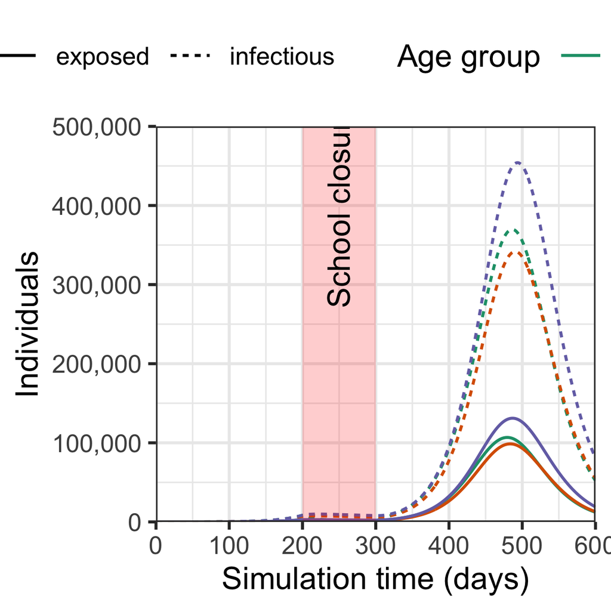

```r
# plot figure of epidemic curve
filter(output, compartment %in% c("exposed", "infectious")) %>%
  ggplot(
    aes(
      x = time,
      y = value,
      col = demography_group,
      linetype = compartment
    )
  ) +
  geom_line() +
  annotate(
    geom = "rect",
    xmin = close_schools$time_begin,
    xmax = close_schools$time_end,
    ymin = 0, ymax = 500e3,
    fill = alpha("red", alpha = 0.2),
    lty = "dashed"
  ) +
  annotate(
    geom = "text",
    x = mean(c(close_schools$time_begin, close_schools$time_end)),
    y = 400e3,
    angle = 90,
    label = "School closure"
  ) +
  scale_y_continuous(
    labels = scales::comma
  ) +
  scale_colour_brewer(
    palette = "Dark2",
    name = "Age group"
  ) +
  expand_limits(
    y = c(0, 500e3)
  ) +
  coord_cartesian(
    expand = FALSE
  ) +
  theme_bw() +
  theme(
    legend.position = "top"
  ) +
  labs(
    x = "Simulation time (days)",
    linetype = "Compartment",
    y = "Individuals"
  )
```